# Series 4 of 10 – Fitting Linear Models - Multiple Regression

Biostatistics R Bayesian Methods JAGS/Stan

Review a simple linear regression using Bayesian Methods  
How to fit a linear multiple regression (Stan) using Bayesian Methods  
Cases of significant/insignificant, correlated and collinear predictors  
Shrinkage  
Bayesian model with or without shrinkage, ridge regression and lasso regression: An example of SAT scores

Hai Nguyen  
January 31, 2022

# Review a simple linear regression in Bayes

We can see [a post](https://hai-mn.github.io/posts/2021-04-22-Simple-linear-regression-in-Bayesian-way/) how to fit a simple linear regression in both Frequentist approach and Bayesian methods. Now we move on to the linear multiple regression.

# Multiple Regression

## Example 1: Two significant predictors

Generate data for multiple linear regression with 2 independent significant predictors.

```r
# generate data
set.seed(03182021)
Ntotal <- 500
x <- cbind(rnorm(Ntotal, mean = 20, sd = 4),
           rnorm(Ntotal, mean=10, sd = 6))
Nx <- ncol(x)
y <- 4 + 1.1*x[,1] + 3*x[,2] + rnorm(Ntotal, mean = 0, sd = 1)
```

Create a data list.

```r
dataListRegression <- list(Ntotal = Ntotal, y = y, x = as.matrix(x), Nx = Nx)
```

Here’s a model in the Frequentist method:

```r
summary(lm(y~x))
```

```
Call:
lm(formula = y ~ x)

Residuals:
     Min       1Q   Median       3Q      Max
-2.83480 -0.63696  0.00131  0.69896  2.48803

Coefficients:
            Estimate Std. Error t value Pr(>|t|)
(Intercept) 4.565419   0.230456   19.81   <2e-16 ***
x1          1.074206   0.010945   98.14   <2e-16 ***
x2          2.995385   0.007954  376.57   <2e-16 ***
---
Signif. codes:  0 '***' 0.001 '**' 0.01 '*' 0.05 '.' 0.1 ' ' 1

Residual standard error: 0.9759 on 497 degrees of freedom
Multiple R-squared:  0.9969,    Adjusted R-squared:  0.9968
F-statistic: 7.895e+04 on 2 and 497 DF,  p-value: < 2.2e-16
```

The diagram of the model shows hierarchical structure with normal priors for intercept $\beta_0$ and slopes $\beta_i$, $i=1,2$.

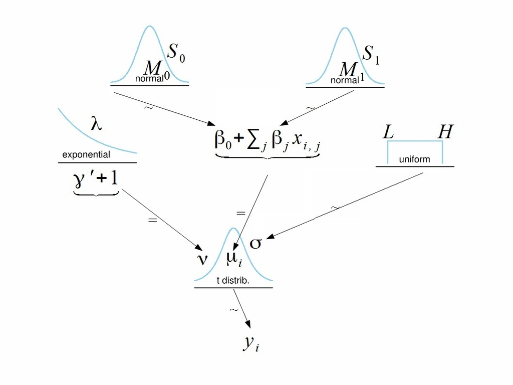

Description of the model:

$$y_i = \beta_0 + \beta_1 x_{i,1} +
\beta_2 x_{i,2} + \epsilon_i \\
y_i \sim t(\mu_i, \sigma, \nu) \\
\\
\text{where mean, scale and degree of freedom, respectively, would be}
\\
\mu_i = \beta_0 + \beta_1 x_{i,1} + \beta_2 x_{i,2} \\
\beta_0 \sim N(M_0, S_0) \ ; \ \beta_j \sim N(M_1, S_1) \\
\sigma \sim Unif(L, H) \\
\nu = \gamma^{\prime} + 1, \ \text{where} \ \gamma^{\prime} \sim
exp(\lambda)$$

Now, we come back to the problem. Here’s we write a model string:

**Reminder of Stan:** (see below, at the end of Example 1)

```r
modelString<-"
data {
    int<lower=1> Ntotal;
    int<lower=1> Nx;
    vector[Ntotal] y;
    matrix[Ntotal, Nx] x;
}
transformed data {
    real meanY;
    real sdY;
    vector[Ntotal] zy; // normalized
    vector[Nx] meanX;
    vector[Nx] sdX;
    matrix[Ntotal, Nx] zx; // normalized

    meanY = mean(y);
    sdY = sd(y);
    zy = (y - meanY) / sdY;
    for (j in 1:Nx) {
        meanX[j] = mean(x[,j]);
        sdX[j] = sd(x[,j]);
        for ( i in 1:Ntotal ) {
            zx[i,j] = (x[i,j] - meanX[j]) / sdX[j];
        }
    }
}
parameters {
    real zbeta0;
    vector[Nx] zbeta;
    real<lower=0> nu;
    real<lower=0> zsigma;
}
transformed parameters{
    vector[Ntotal] zy_hat;
    zy_hat = zbeta0 + zx * zbeta;
}
model {
    zbeta0 ~ normal(0, 2);
    zbeta  ~ normal(0, 2);
    nu ~ exponential(1/30.0);
    zsigma ~ uniform(1.0E-5 , 1.0E+1);
    zy ~ student_t(1+nu, zy_hat, zsigma);
}
generated quantities {
    // Transform to original scale:
    real beta0;
    vector[Nx] beta;
    real sigma;
    // .* and ./ are element-wise product and divide
    beta0 = zbeta0*sdY  + meanY - sdY * sum( zbeta .* meanX ./ sdX );
    beta = sdY * ( zbeta ./ sdX );
    sigma = zsigma * sdY;
} "
```

```r
RobustMultipleRegressionDso <- stan_model(model_code=modelString)
```

If saved DSO is used load it, then run the chains.

```r
# saveRDS(RobustMultipleRegressionDso, file="data/DSORobustMultRegr.Rds")
RobustMultipleRegressionDso <- readRDS("data/DSORobustMultRegr.Rds")
```

Fit the model.

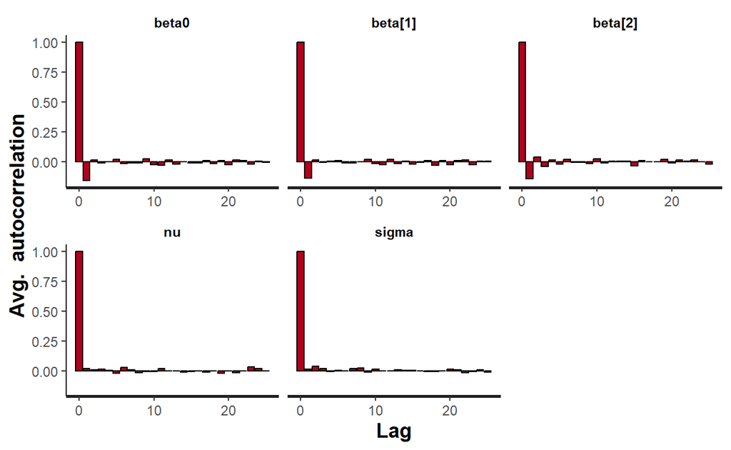

```r
fit1 <- sampling(RobustMultipleRegressionDso,
                 data=dataListRegression,
                 pars=c('beta0', 'beta', 'nu', 'sigma'),
                 iter = 5000, chains = 2, cores = 2)
stan_ac(fit1)
```

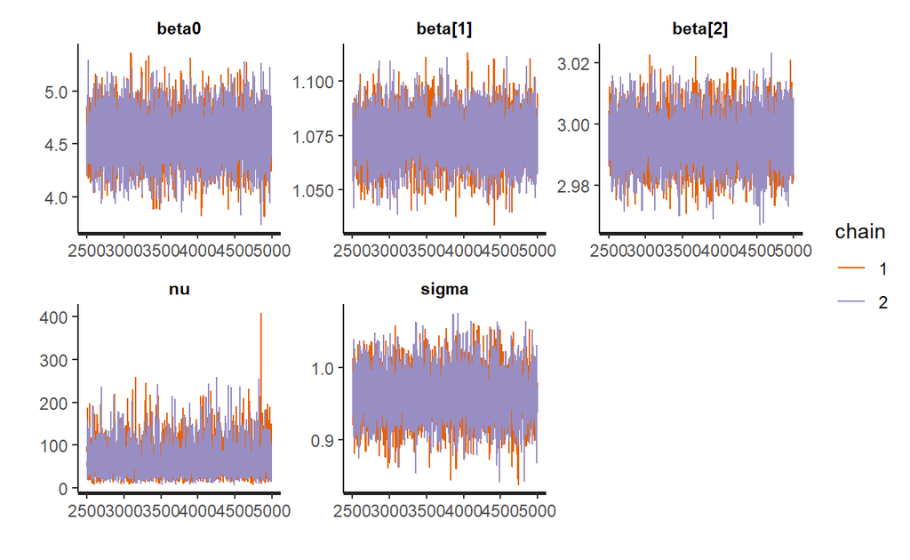

```r
stan_trace(fit1)
```

Look at the results.

```r
summary(fit1)$summary[,c(1,3,4,5,8,9)] #mean, sd, 2.5%, 97.5%, n_eff
```

```
                mean           sd         2.5%         25%
beta0      4.5780310  0.231357219    4.1304172    4.422841
beta[1]    1.0738282  0.011006048    1.0521979    1.066428
beta[2]    2.9951527  0.008047017    2.9797451    2.989759
nu        61.7987150 36.009712586   17.0095629   36.082778
sigma      0.9611543  0.032896641    0.8978996    0.938909
lp__    1014.2033841  1.585209650 1010.1168812 1013.426674
              97.5%    n_eff
beta0      5.025614 7033.830
beta[1]    1.095054 6561.254
beta[2]    3.011046 6871.816
nu       151.390448 4557.868
sigma      1.027262 4328.823
lp__    1016.293483 2600.401
```

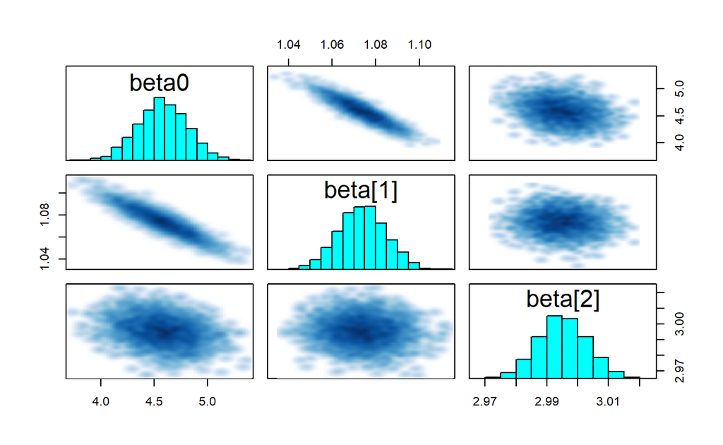

```r
pairs(fit1,pars=c("beta0","beta[1]","beta[2]"))
```

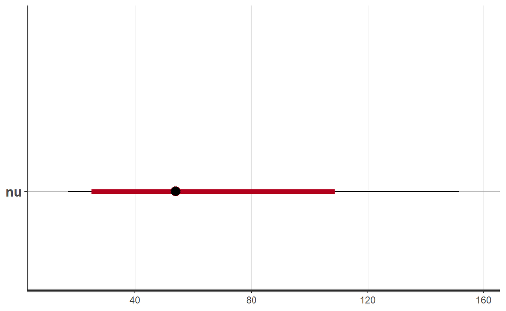

```r
plot(fit1,pars="nu")
```

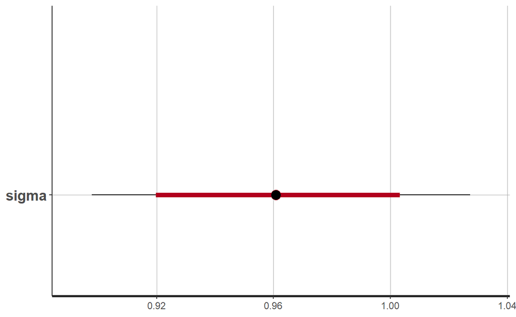

```r
plot(fit1,pars="sigma")
```

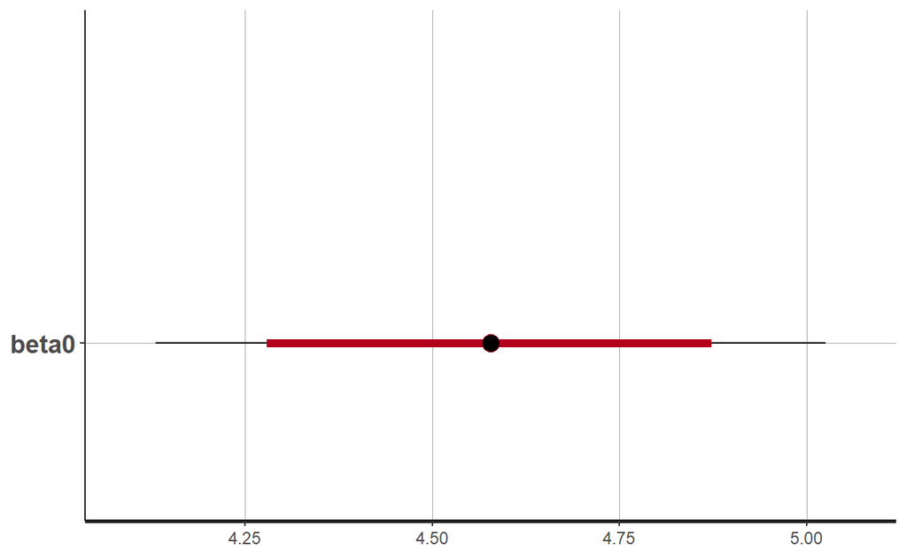

```r
plot(fit1,pars="beta0")
```

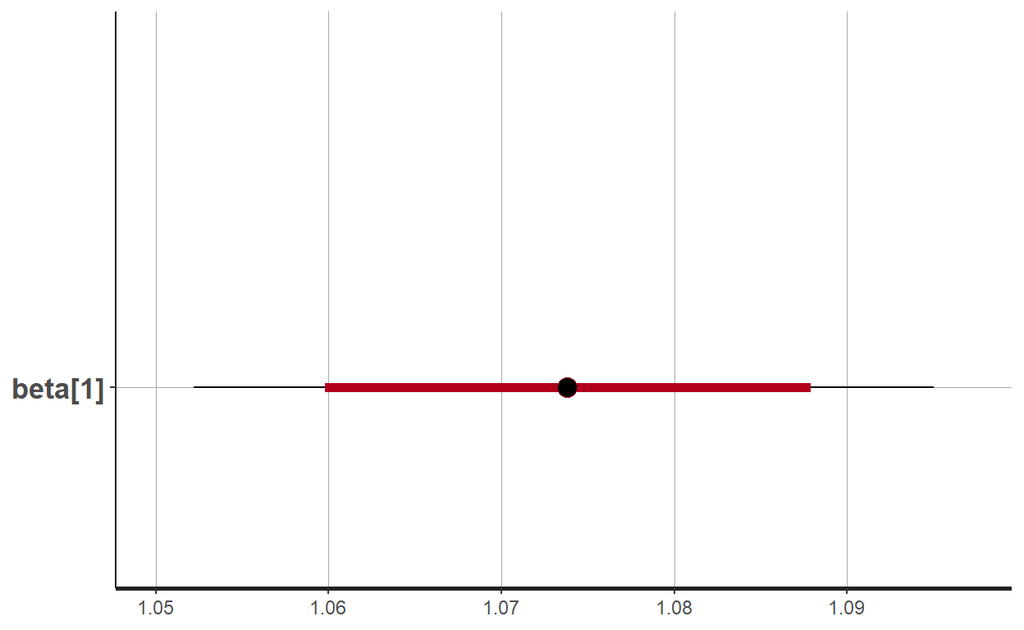

```r
plot(fit1,pars="beta[1]")
```

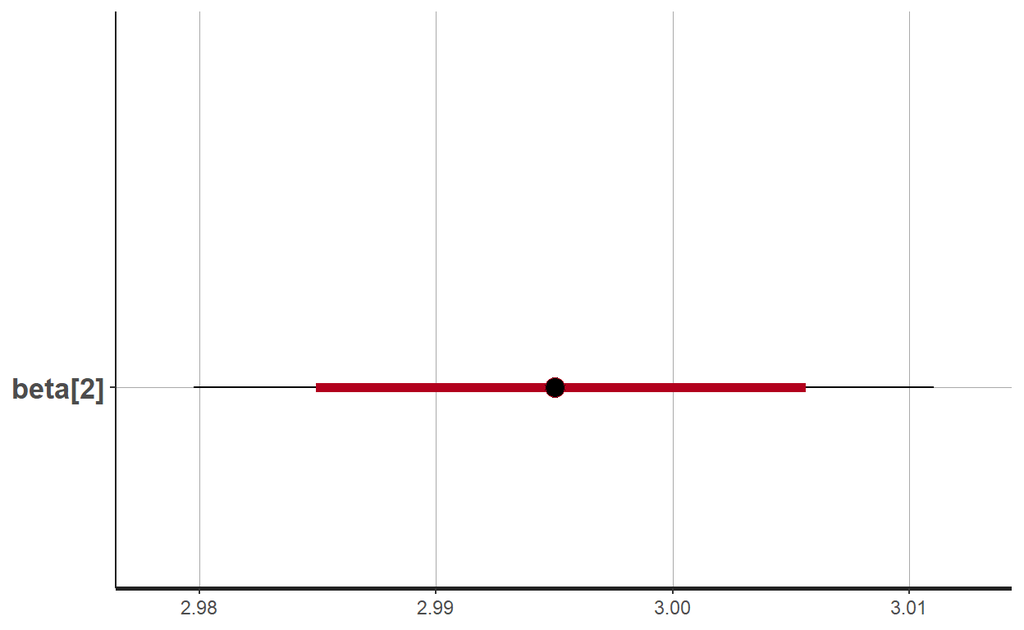

```r
plot(fit1,pars="beta[2]")
```

Analyze fitted model using `shinystan`

```r
launch_shinystan(fit1)
```

### Reminder of Stan

A `Stan` program has three required “blocks”:

1. `data` block: where you declare the data types, their dimensions, any restrictions (i.e. upper = or lower = , which act as checks for `Stan`), and their names. Any names you give to your `Stan` program will also be the names used in other blocks.
2. `parameters` block: This is where you indicate the parameters you want to model, their dimensions, restrictions, and name. For a linear regression, we will want to model the intercept, any slopes, and the standard deviation of the errors around the regression line.
3. `model` block: This is where you include any sampling statements, including the “likelihood” (model) you are using. The model block is where you indicate any prior distributions you want to include for your parameters. If no prior is defined, `Stan` uses default priors with the specifications `uniform(-infinity, +infinity)`. You can restrict priors using upper or lower when declaring the parameters (i.e. `<lower = 0>` to make sure a parameter is positive). You can find more information about prior specification [here](https://github.com/stan-dev/stan/wiki/Prior-Choice-Recommendations).

Sampling is indicated by the `~` symbol, and Stan already includes many common distributions as vectorized functions. You can check out [the manual](https://mc-stan.org/users/documentation/) for a comprehensive list and more information on the optional blocks you could include in your `Stan` model.

There are also four optional blocks:

- `functions`
- `transformed data`: allows for preprocessing of the data
- `transformed parameters`: allows for parameter processing before the posterior is computed

Objects declared in the “transformed parameters” block of a Stan program are:

1. Unknown but are known given the values of the objects in the parameters block
2. Saved in the output and hence should be of interest to the researcher
3. Are usually the arguments to the log-likelihood function that is evaluated in the `model` block, although in hierarchical models the line between the prior and the likelihood can be drawn in multiple ways

(if the third point is not the case, the object should usually be declared in the `generated quantities` block of a Stan program)

- “generated quantities”

$\Rightarrow$ Transformation to improve fit Comments are indicated by `//` in `Stan.` The `write("model code", "file_name")` bit allows us to write the Stan model in our R script and output the file to the working directory (or you can set a different file path)

## Example 2: Insignificant predictor

```r
Regression.Data <- as.matrix(read.csv("data/DtSim4RegANOVA.csv", header=TRUE, sep=","))
tail(Regression.Data)
```

```
          Output     Input1      Input2
[495,] 2.4054442  0.9276934  0.07278244
[496,] 1.8663026 -0.3678520  1.51715986
[497,] 1.3590146  0.5369795  0.96209003
[498,] 3.1836007  1.0171332 -0.56660564
[499,] 2.3615061  1.1637966  0.07815352
[500,] 0.8483407  1.1775607  1.59720356
```

Prepare the data for Stan.

```r
Ntotal <- nrow(Regression.Data)
x <- Regression.Data[ ,2:3]
tail(x)
```

```
           Input1      Input2
[495,]  0.9276934  0.07278244
[496,] -0.3678520  1.51715986
[497,]  0.5369795  0.96209003
[498,]  1.0171332 -0.56660564
[499,]  1.1637966  0.07815352
[500,]  1.1775607  1.59720356
```

```r
Nx <- ncol(x)
y <- Regression.Data[ ,1]
dataListInsig <- list(Ntotal=Ntotal,
                      y=y,
                      x=as.matrix(x),
                      Nx=Nx)
```

Run MCMC using the same DSO.

```r
fit2 <- sampling(RobustMultipleRegressionDso, data=dataListInsig,
                 pars=c('beta0', 'beta', 'nu', 'sigma'),
                 iter=5000, chains = 2, cores = 2)
```

```r
launch_shinystan(fit2)
```

Analyze the results.

```r
summary(fit2)$summary[,c(1,3,4,8,9)] #mean, sd, 2.5%, 97.5%, n_eff
```

```
                 mean          sd          2.5%         97.5%
beta0    1.217597e+00  0.05182680    1.11612951    1.31636194
beta[1]  7.999726e-01  0.02812159    0.74453626    0.85437808
beta[2]  9.416795e-03  0.02736786   -0.04397004    0.06323134
nu       5.276307e+01 34.06776500   13.74259262  142.96095320
sigma    5.979875e-01  0.02144590    0.55558445    0.64151495
lp__    -1.817471e+02  1.53474481 -185.40442023 -179.67956203
           n_eff
beta0   5838.281
beta[1] 6158.199
beta[2] 5787.610
nu      4567.018
sigma   4814.577
lp__    2650.410
```

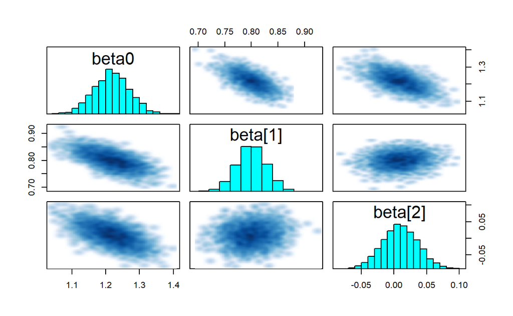

```r
pairs(fit2,pars=c("beta0","beta[1]","beta[2]"))
```

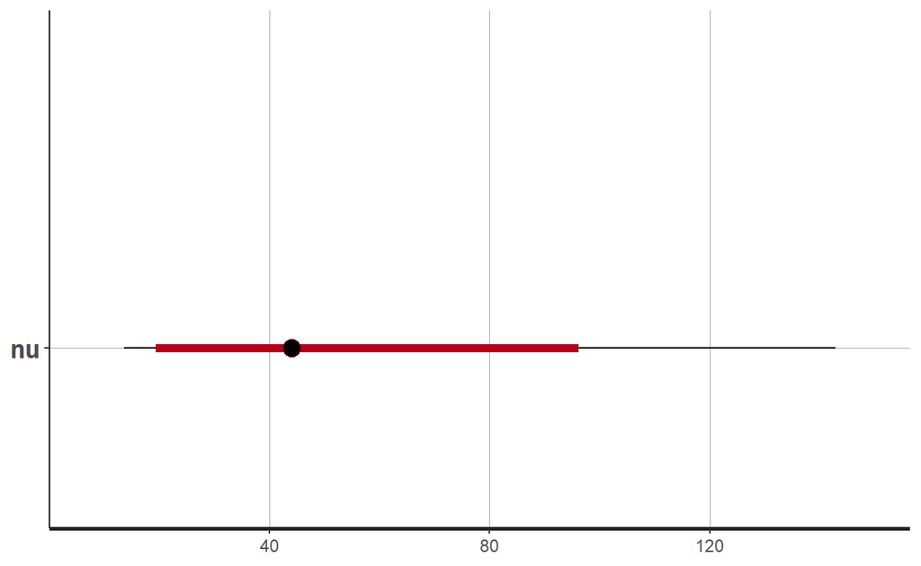

```r
plot(fit2,pars="nu")
```

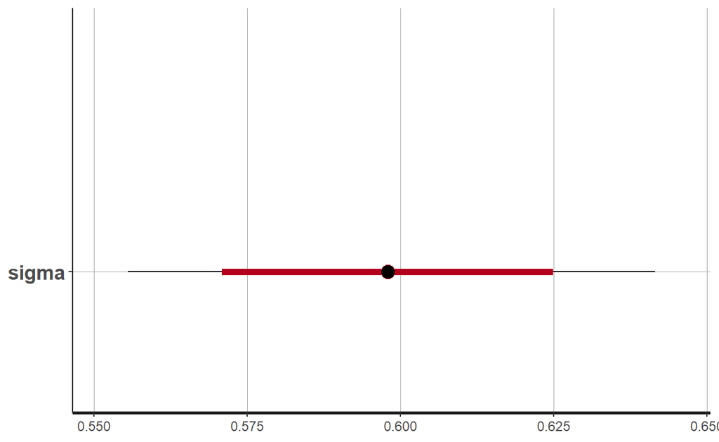

```r
plot(fit2,pars="sigma")
```

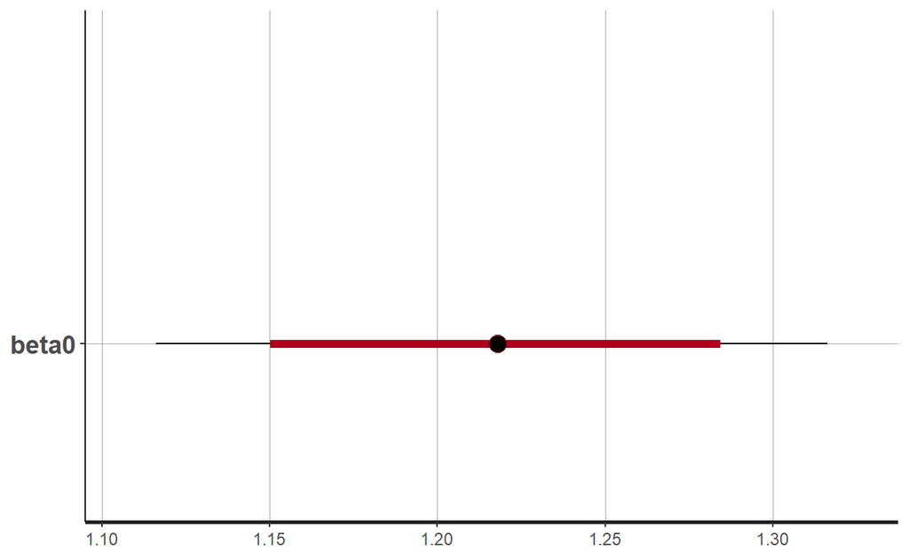

```r
plot(fit2,pars="beta0")
```

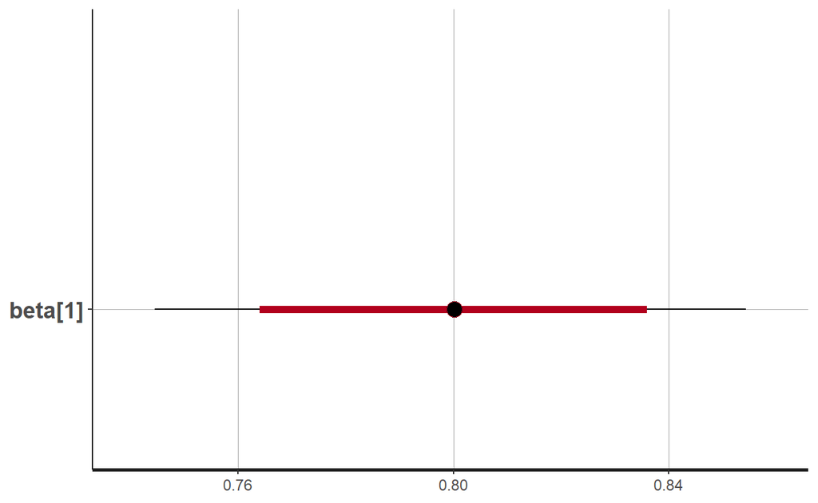

```r
plot(fit2,pars="beta[1]")
```

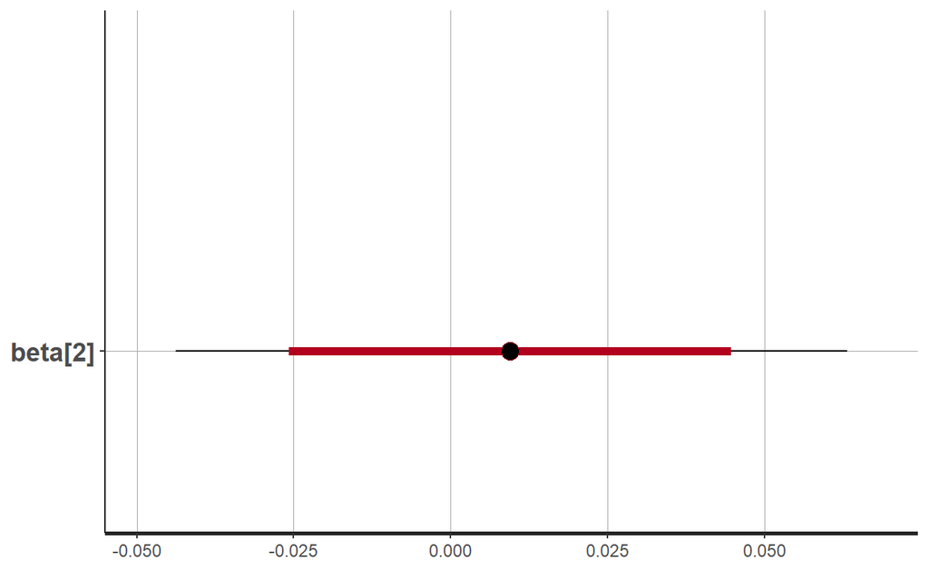

```r
plot(fit2,pars="beta[2]")
```

We see that parameter $\beta_2$ is not significant.  
However, there is no strong correlation or redundancy between the predictors.

Compare with the output of linear model

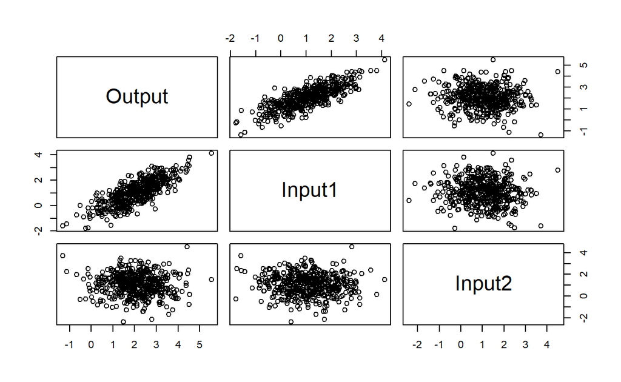

```r
pairs(Regression.Data)
```

```r
summary(lm(Output~., data=as.data.frame(Regression.Data)))
```

```
Call:
lm(formula = Output ~ ., data = as.data.frame(Regression.Data))

Residuals:
     Min       1Q   Median       3Q      Max
-1.76631 -0.39358 -0.01411  0.40432  1.91861

Coefficients:
            Estimate Std. Error t value Pr(>|t|)
(Intercept)  1.21480    0.05179  23.458   <2e-16 ***
Input1       0.80116    0.02819  28.423   <2e-16 ***
Input2       0.00970    0.02787   0.348    0.728
---
Signif. codes:  0 '***' 0.001 '**' 0.01 '*' 0.05 '.' 0.1 ' ' 1

Residual standard error: 0.6107 on 497 degrees of freedom
Multiple R-squared:  0.6204,    Adjusted R-squared:  0.6188
F-statistic: 406.1 on 2 and 497 DF,  p-value: < 2.2e-16
```

## Example 3: Correlated predictors

### Strong correlation

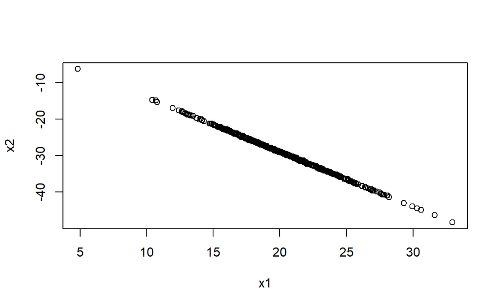

```r
set.seed(03192021)
Ntotal <- 500
x1 <- rnorm(Ntotal, mean = 20, sd = 4)
x2 <- 1 - 1.5*x1 + rnorm(Ntotal, mean=0, sd = .1)
x <- cbind(x1,x2)

plot(x)
```

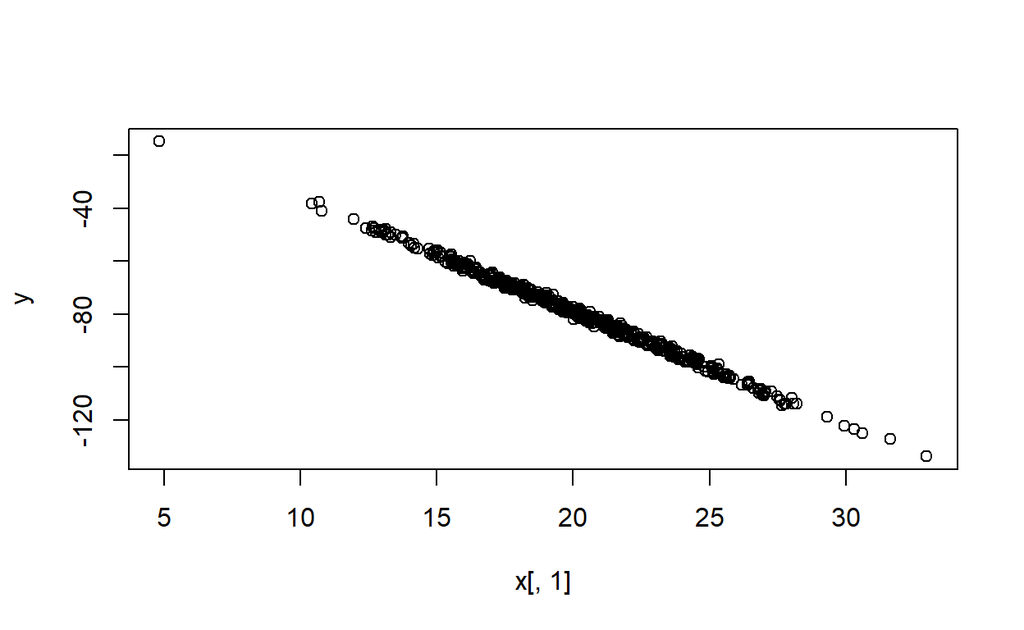

```r
Nx <- ncol(x)
y <- 4 + .2*x[,1] + 3*x[,2]+rnorm(Ntotal, mean = 0, sd = 1)
plot(x[,1],y)
```

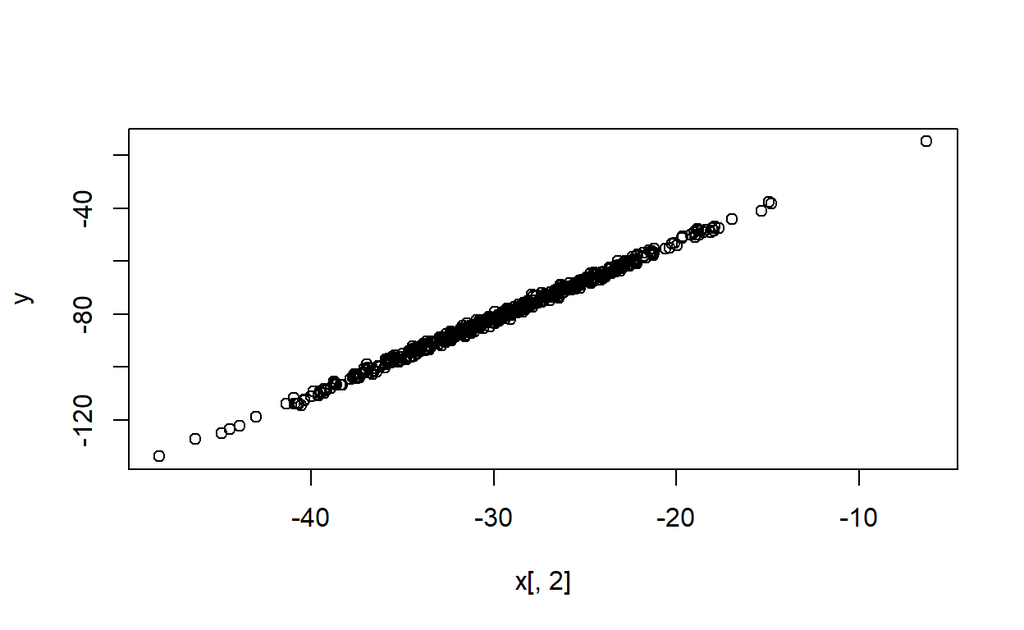

```r
plot(x[,2],y)
```

```r
fitlm<-lm(y~x[,1]+x[,2])
summary(fitlm)
```

```
Call:
lm(formula = y ~ x[, 1] + x[, 2])

Residuals:
    Min      1Q  Median      3Q     Max
-2.7765 -0.7585  0.0172  0.6577  3.1721

Coefficients:
            Estimate Std. Error t value Pr(>|t|)
(Intercept)   4.5619     0.4878   9.353  < 2e-16 ***
x[, 1]       -0.5468     0.6707  -0.815    0.415
x[, 2]        2.5034     0.4479   5.589 3.76e-08 ***
---
Signif. codes:  0 '***' 0.001 '**' 0.01 '*' 0.05 '.' 0.1 ' ' 1

Residual standard error: 0.9988 on 497 degrees of freedom
Multiple R-squared:  0.9962,    Adjusted R-squared:  0.9962
F-statistic: 6.53e+04 on 2 and 497 DF,  p-value: < 2.2e-16
```

```r
drop1(fitlm)
```

```
Single term deletions

Model:
y ~ x[, 1] + x[, 2]
       Df Sum of Sq    RSS     AIC
<none>              495.85  1.8338
x[, 1]  1    0.6632 496.51  0.5021
x[, 2]  1   31.1702 527.02 30.3165
```

```r
dataListShrink2 <- list(Ntotal=Ntotal, y=y, x=as.matrix(x), Nx=Nx)
```

Note that actual coefficient for `x[,1]` is $+0.2$, but slope on the plot plot(x[,1],y) is negative.  
Also note that **estimated model coefficients are different from actual because of correlation**:

```r
cbind(actual=c(4,.2,3),estimated=fitlm$coefficients)
```

```
            actual  estimated
(Intercept)    4.0  4.5619222
x[, 1]         0.2 -0.5468278
x[, 2]         3.0  2.5034438
```

Run the chains and analyze the results.

```r
tStart<-proc.time()
fit3<-sampling(RobustMultipleRegressionDso,
               data = dataListShrink2,
               pars = c('beta0', 'beta', 'nu', 'sigma'),
               iter = 5000, chains = 2, cores = 2)
tEnd<-proc.time()
tEnd-tStart
```

```
   user  system elapsed
   0.51    0.39   92.09
```

**How long did it take to run this MCMC? Why so long?**

Monte Carlo methods assume that the samples are independent. This is usually not the case for sequential draws in Markov Chain Monte Carlo (MCMC) sampling, motivating the use of thinning. In thinning, we keep every T sample ($P(x \le t)$) and throw away the other samples. For some types of MCMC (notably, Gibbs sampling), highly correlated variables result in highly correlated samples (i.e., definitely not independent), requiring a large T to compensate. Large values of T mean a large computational cost for each effective sample (i.e., for each sample that is kept).

*Note:* The parameter thin allows the user to specify if and how much the MCMC chains should be thinned out before storing them. By default thin = 1 is used, which corresponds to keeping all values. A value thin = 10 would result in keeping every 10th value and discarding all other values.

Check convergence in shiny.

```r
launch_shinystan(fit3)
```

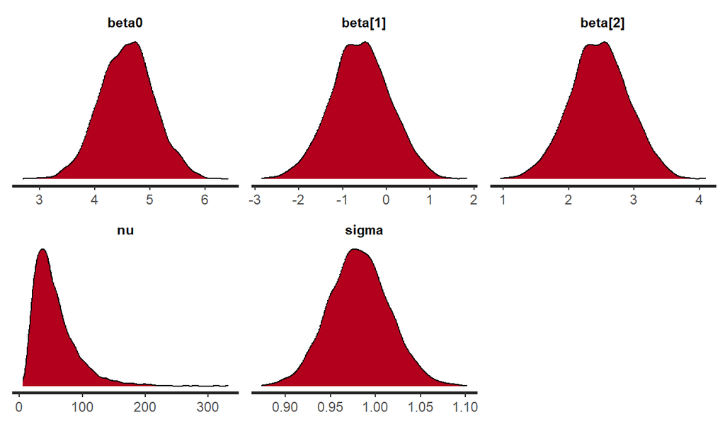

```r
stan_dens(fit3)
```

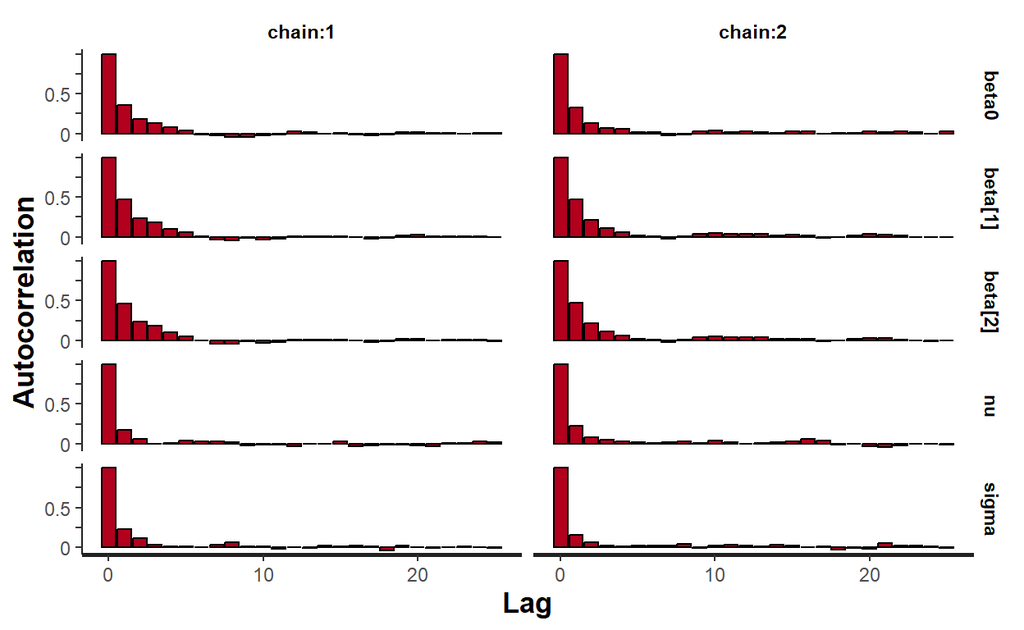

```r
stan_ac(fit3, separate_chains = T)
```

```r
summary(fit3)$summary[,c(1,3,4,8,9)]
```

```
               mean          sd        2.5%       97.5%    n_eff
beta0     4.5857595  0.48813790   3.6314232   5.5544965 2114.939
beta[1]  -0.5967437  0.67710628  -1.9314954   0.7388229 1713.891
beta[2]   2.4699613  0.45229741   1.5765319   3.3619226 1712.967
nu       56.0426640 33.61895666  15.8382163 143.5659182 2718.137
sigma     0.9816801  0.03355264   0.9166907   1.0483195 2731.866
lp__    967.3463697  1.56455325 963.5132940 969.3727437 1911.020
```

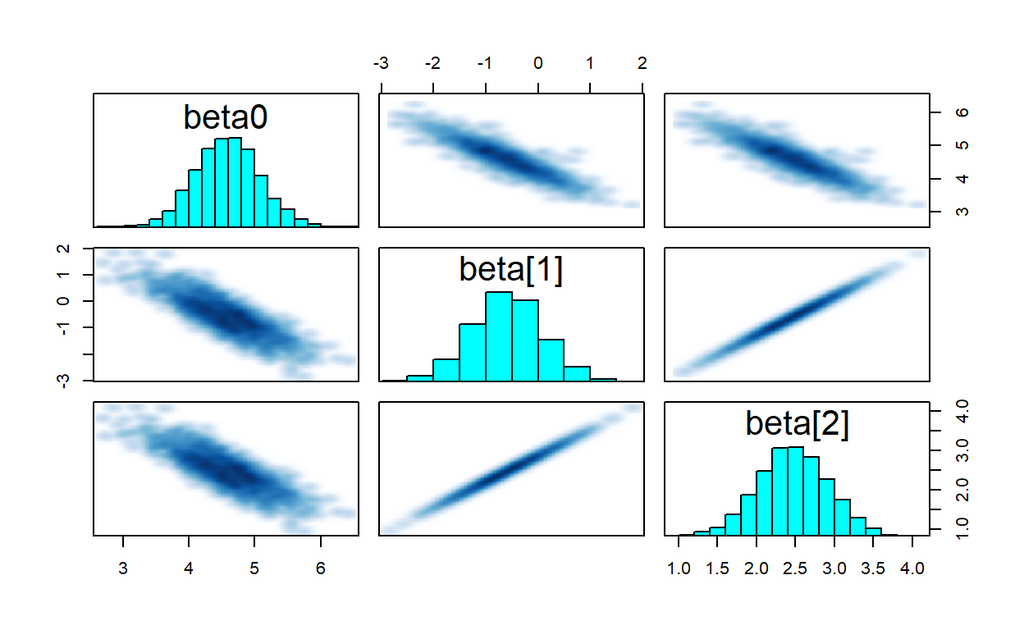

```r
pairs(fit3,pars=c("beta0","beta[1]","beta[2]"))
```

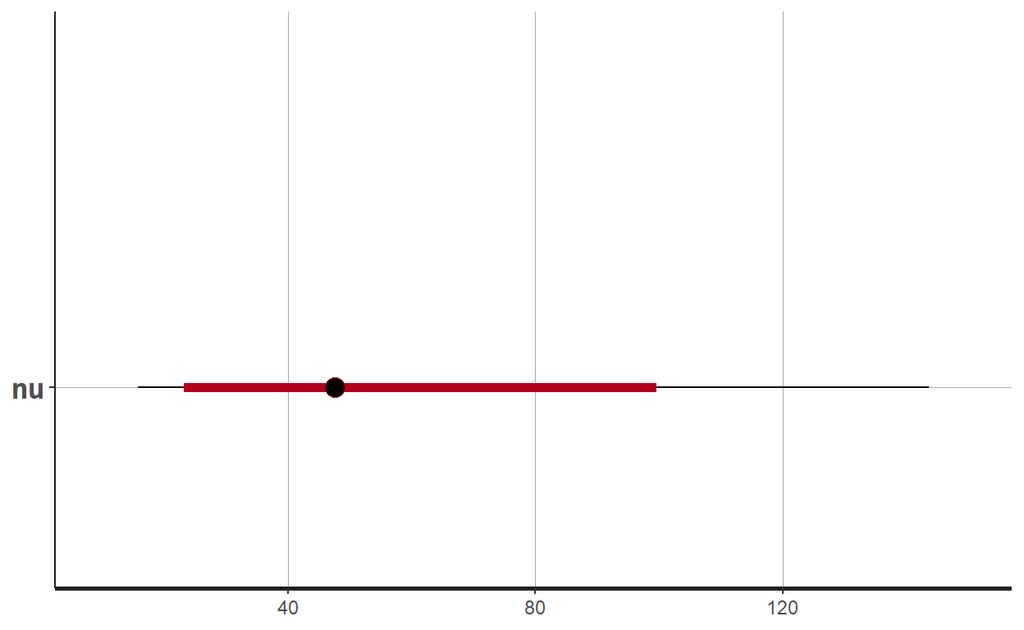

```r
plot(fit3,pars="nu")
```

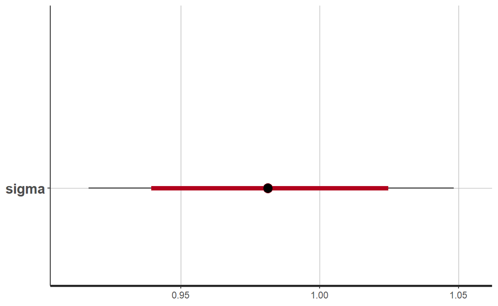

```r
plot(fit3,pars="sigma")
```

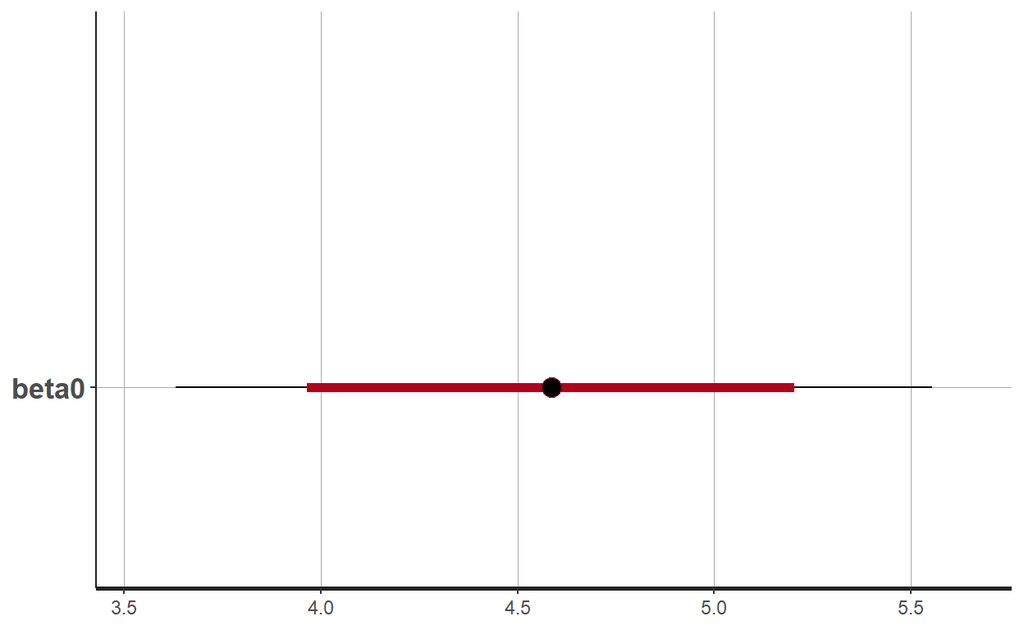

```r
plot(fit3,pars="beta0")
```

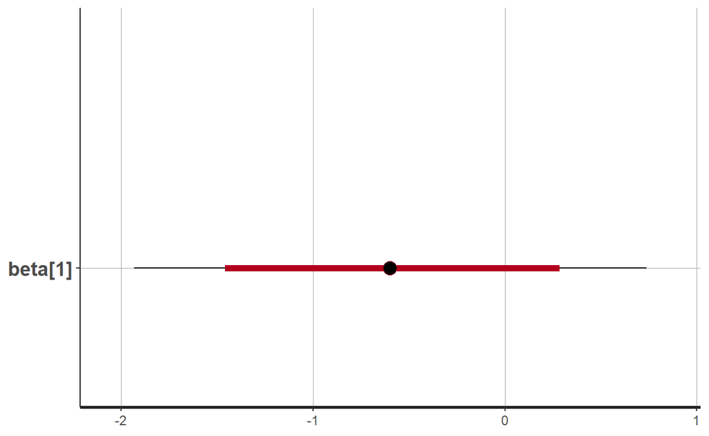

```r
plot(fit3,pars="beta[1]")
```

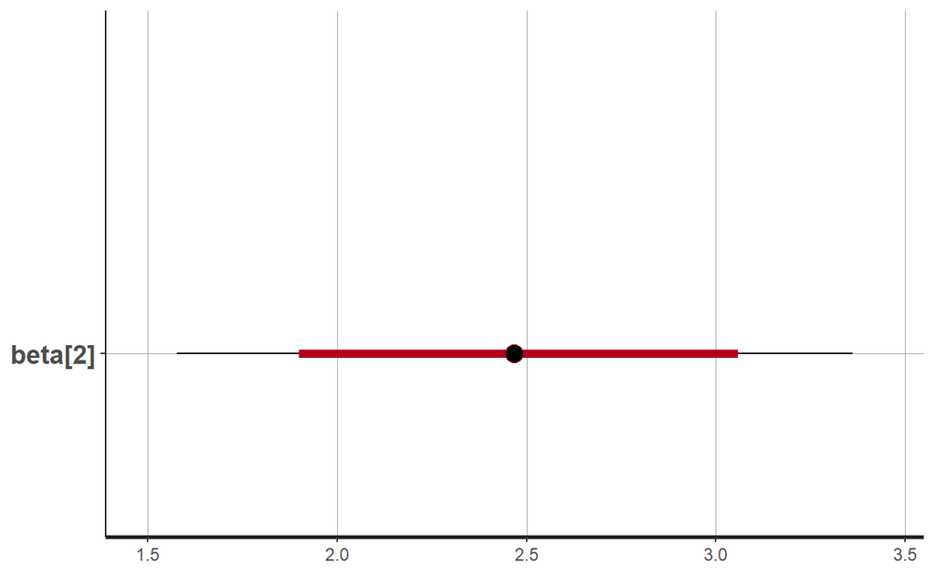

```r
plot(fit3,pars="beta[2]")
```

> General signs of collinear predictors:  
> - High correlation between slopes (compensating sign)  
> - Wide posterior distributions for slopes  
> - Increased autocorrelation for slopes

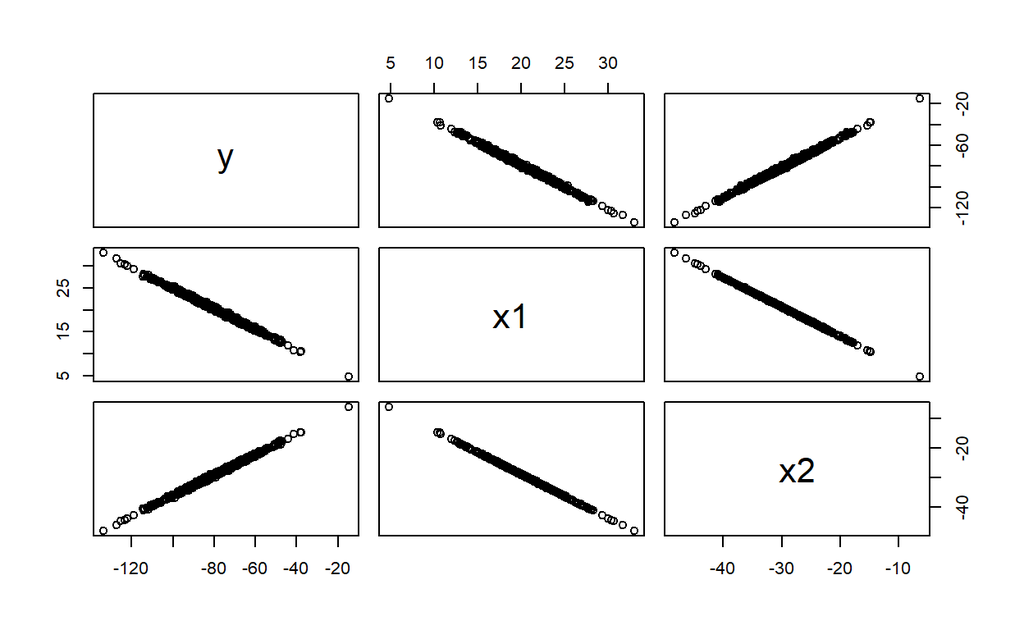

```r
pairs(cbind(y,x1,x2))
```

```r
cbind(actual=c(4,.2,3),estimatedLm=fitlm$coefficients,estimatedBayes=summary(fit3)$summary[1:3,1])
```

```
            actual estimatedLm estimatedBayes
(Intercept)    4.0   4.5619222      4.5857595
x[, 1]         0.2  -0.5468278     -0.5967437
x[, 2]         3.0   2.5034438      2.4699613
```

Linear model shows the same information as Bayesian.

### Collinearity

In case when predictors have strong collinearity, linear model may stop working.  
Simulate the same model as in the previous section, but make predictors collinear.

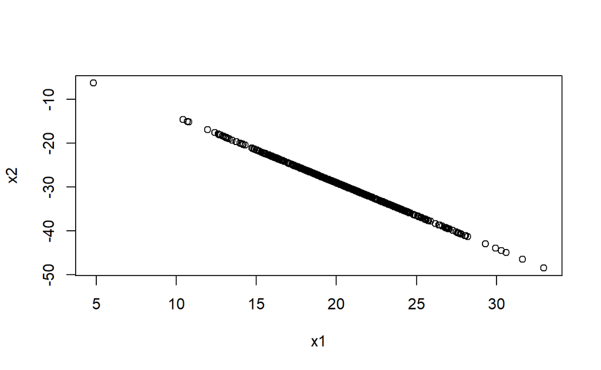

```r
set.seed(03192021)
Ntotal <- 500
x1 <- rnorm(Ntotal, mean = 20, sd = 4)
x2<-1-1.5*x1+rnorm(Ntotal, mean=0, sd = .000001) # sd closes to 0
x<-cbind(x1,x2)
plot(x)
```

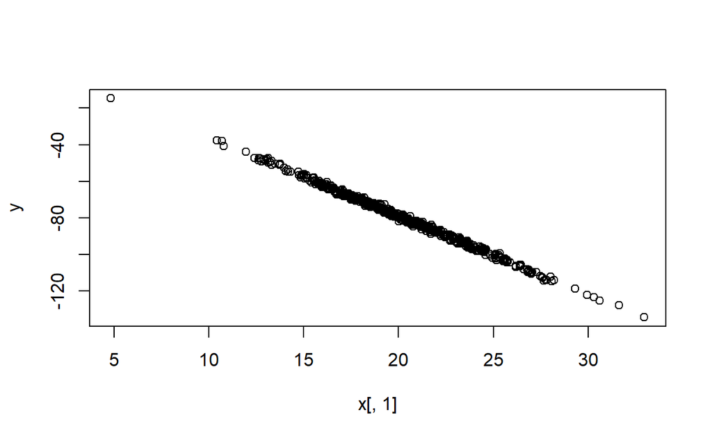

```r
Nx <- ncol(x)
y <- 4 + .2*x[,1] + 3*x[,2]+rnorm(Ntotal, mean = 0, sd = 1)
plot(x[,1],y)
```

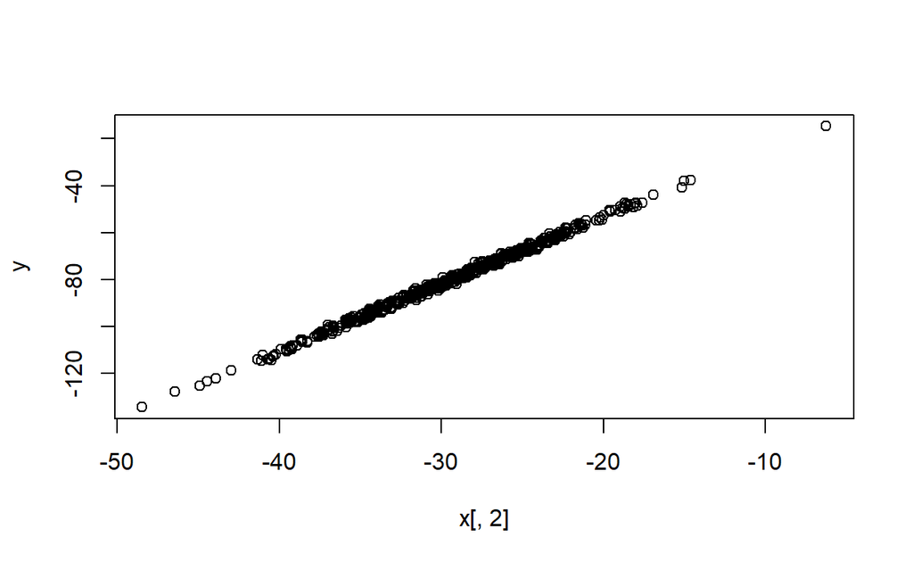

```r
plot(x[,2],y)
```

```r
dataListShrink2c <- list(Ntotal=Ntotal, y=y, x=as.matrix(x), Nx=Nx)
(lmFit <- lm(y~x1+x2))
```

```
Call:
lm(formula = y ~ x1 + x2)

Coefficients:
(Intercept)           x1           x2
      7.094       -4.303           NA
```

```r
summary(lmFit)
```

```
Call:
lm(formula = y ~ x1 + x2)

Residuals:
    Min      1Q  Median      3Q     Max
-2.7626 -0.7636  0.0244  0.6410  3.1747

Coefficients: (1 not defined because of singularities)
            Estimate Std. Error t value Pr(>|t|)
(Intercept)  7.09394    0.24447   29.02   <2e-16 ***
x1          -4.30334    0.01189 -361.96   <2e-16 ***
x2                NA         NA      NA       NA
---
Signif. codes:  0 '***' 0.001 '**' 0.01 '*' 0.05 '.' 0.1 ' ' 1

Residual standard error: 0.9991 on 498 degrees of freedom
Multiple R-squared:  0.9962,    Adjusted R-squared:  0.9962
F-statistic: 1.31e+05 on 1 and 498 DF,  p-value: < 2.2e-16
```

```r
drop1(lmFit)
```

```
Single term deletions

Model:
y ~ x1 + x2
       Df Sum of Sq    RSS    AIC
<none>              497.08 1.0687
x1      0 0.0001417 497.08 1.0688
x2      0 0.0000000 497.08 1.0687
```

Linear model stops working.